# Lego Assembly Thesis Analysis

Amy Rae Fox & Zoe Kothari

2026-05-06

## OPEN QUESTIONS

### step complexity

- X complexity score import
- X complexity score join to step duration
- todo something with step repeats / frequency

### by participant

- by participant experience
- by corsi
- participant strategy mean step 0 time step 0 team

### error pairs

- X time——accuracy – import error pairs
- Do ppl who have fewer step repeats have more errors? (visualization of ERRORS X STEP frequency by person) ### step pairs
- import step-pairs
- strategy X errors

## SETUP

### import lookup tables

```r
## IMPORT STEP COMPLEXITY
lookup_step <- read_csv("data/input/lookup_step_complexity.csv", col_select = c('Step','complexity_score', 'complexity_category','Step_Code')) %>%
  mutate(
    STEP = as_factor(Step),
    STEP_CODE = as_factor(Step_Code),
    COMPLEXITY = as_factor(complexity_category)
  ) %>% select(-Step,-Step_Code, -complexity_category)
## IMPORT ERROR CODES
lookup_errors <- read_csv("data/input/lookup_errors.csv") %>%
  mutate(across(where(is.character), as.factor))
```

### import steps

```r
## DF_STEPS_RAW
## maxQDA export of all retrieved segments for the query (all documents) + (highest level step code [includes each numbered step + Step Repeat + Flipping/Tapping Through Fast])
## NOTE: need to handle Step Repeat + Flipping/Tapping Through Fast seperately
df_steps_raw <- read_csv("data/input/wip_steps.csv", col_select =
                       c(`Document name`,
                         `Code`,
                        `Beginning`,
                        `End`
                         ),
                     show_col_types=FALSE) %>%
    rename(
      START =  `Beginning`,
      END = `End`
    ) %>%
    separate('Document name', into = c("PID", "JAR","FORMAT"), sep = "_") %>%
    separate('Code', into = c("MASTER_STEP", "STEP"), sep = '>') %>%
    ## strip weird end stuff from times
    # separate(END, into = c("END", "JUNK"), sep = ',') %>%
    # separate(START, into = c("START", "JUNK"), sep = ',') %>%
  mutate(
    PID = as_factor(PID),
    JAR = as_factor(JAR),
    FORMAT = as_factor(FORMAT),
    # ERROR_GROUP = as_factor(str_trim(ERROR_GROUP)),
    STEP = as_factor(str_trim(STEP)),
    # MASTER_STEP = as_factor(MASTER_STEP),
    START = gsub(",", ".", START),
    START = hms::as_hms(START),
    END   = gsub(",", ".", END),
    END = hms::as_hms(END),
    DURATION = as.numeric(END-START, units = "secs")
  ) |>
## CREATE ORDER FACTOR
  mutate(
    ORDER = case_when(
      (JAR == "jar1" & FORMAT == "B") |
      (JAR == "jar2" & FORMAT == "A") ~ "BOOK_FIRST",

      (JAR == "jar1" & FORMAT == "A") |
      (JAR == "jar2" & FORMAT == "B") ~ "APP_FIRST"),
  ORDER = factor(ORDER),
  ORDER = forcats::fct_rev(ORDER)) %>%
## FILTER OUT P11 [APP ONLY CONTROL] // P18 [BOOK ONLY CONTROL]
  filter(PID %nin% c("P11", "P18"))%>%
## REORDER STEP FACTOR LEVELS
  mutate(
    STEP = fct_relevel(STEP, "Step 0A","Step 0B")
  ) |>
  select(-MASTER_STEP) |>
  left_join(
    lookup_step,
    by = "STEP"
  ) %>%
  droplevels()


## RENAME INSTRUCTION TYPES
df_steps_raw$FORMAT <- fct_recode(df_steps_raw$FORMAT,
                            "APP" = 'A',
                            "BOOKLET" = 'B')

## DF_STEP_REPEATS
## The Step Repeat is a dual code (alongside the numbered step), applied whenever a participant meaninfully repeated the actions of a step while looking at the instructions for the step (e.g. potentially during an error recovery)
## NOT included in PARTICIPANT count of steps (dual code would add doubles)
## NOT included in PARTICIPANT step-level duration (dual code would add doubles)
df_step_repeats <- df_steps_raw |>
  filter( STEP == "Step Repeat")


## DF_STEP_FLIPPING
## The 'Flipping/Tapping Through Fast code indicates when participant is engaging with instructions in order to navigate to a different point rather than meaningfully with THAT step
## NOTE flipping/tapping SHOULD be included in Participant level total step duration
## NOTE flipping/tapping SHOULD NOT be included in Participant level step count
df_step_flipping <- df_steps_raw |>
  filter( STEP == "Flipping/Tapping Through Fast")


##DF_STEPS_COUNT
##data frame for time coded on a step; includes 'repeats' but not explicitly coded as repeat
## instances of each step code excluding (dual-coded) step repeat + flip
## NOTE flipping/tapping SHOULD NOT be included in Participant level step count
## primary DF for step level analysis
df_steps_count <- df_steps_raw %>%
  filter(STEP %nin% c("Step Repeat", "Flipping/Tapping Through Fast")) |>
  droplevels()


## FOR STEP DURATION GRAPHS
## NOTE flipping/tapping SHOULD be included in Participant level total step duration
df_steps_duration <- df_steps_raw %>%
  filter(STEP %nin% c("Step Repeat")) |>
  droplevels()

## EXPORT DF_STEPS
write.csv(df_steps_count,"data/output/df_steps_count.csv", row.names = FALSE)
write.csv(df_steps_duration,"data/output/df_steps_duration.csv", row.names = FALSE)


## CLEANUP
rm(df_steps_raw)
```

### import errors

```r
##import errors
## maxQDA export of all retrieved segments for the query (all documents) + (highest level Errors group code [deselect Error Pairs])
## includes error-codes + Error Types + Error Recovery
df_errors_raw <- read_csv("data/input/wip_errors.csv", col_select =
                       c(`Document name`,
                         `Code`,
                        `Beginning`,
                        `End`
                         ),
                     show_col_types=FALSE) %>%
    rename(
      START =  `Beginning`,
      END = `End`
    ) %>%
    separate('Document name', into = c("PID", "JAR","FORMAT"), sep = "_") %>%
    separate('Code', into = c("BLANK","ERROR_GROUP", "ERROR_TYPE","ERROR"), sep = '>') %>%
    ## strip weird end stuff from times
    # separate(END, into = c("END", "JUNK"), sep = ',') %>%
    # separate(START, into = c("START", "JUNK"), sep = ',')  %>%
  ## FILTER OUT P11 [APP ONLY CONTROL] // P18 [BOOK ONLY CONTROL]
  filter(PID %nin% c("P11", "P18"))%>%
  mutate(
    PID = as_factor(PID),
    JAR = as_factor(JAR),
    FORMAT = as_factor(FORMAT),
    START = gsub(",", ".", START),
    START = hms::as_hms(START),
    END   = gsub(",", ".", END),
    END = hms::as_hms(END),
    DURATION = as.numeric(END-START, units = "secs"),
    ERROR_GROUP = as_factor(str_trim(ERROR_GROUP)),
    ERROR_TYPE = as_factor(str_trim(ERROR_TYPE)),
    ERROR = as_factor(str_trim(ERROR))
  ) %>%
  ## CREATE ORDER FACTOR
  mutate(
    ORDER = case_when(
      (JAR == "jar1" & FORMAT == "B") |
      (JAR == "jar2" & FORMAT == "A") ~ "BOOK_FIRST",

      (JAR == "jar1" & FORMAT == "A") |
      (JAR == "jar2" & FORMAT == "B") ~ "APP_FIRST"),
  ORDER = factor(ORDER),
  ORDER = forcats::fct_rev(ORDER)) %>%
  select(-BLANK)
## RENAME INSTRUCTION TYPES
df_errors_raw$FORMAT <- fct_recode(df_errors_raw$FORMAT,
                            "APP" = 'A',
                            "BOOKLET" = 'B')



## participant level total error count --> sum df_errors w/o error recovery or unresolved
## participant level unresolved error code --> sum UNRESOLVED UPON COMPLETION


## DF_ERROR_RECOVERIES
## Error Recovery portion of time when a participant is remediating the error //
## Unresolved Completion is dual/triple coded with the original error code if they don't recover from it (co-occurs w/ error type)
## only frequency; step codes intersection is not going to be accurate bc it will overlap with wrong step code
df_error_recoveries <- df_errors_raw %>%
  filter(ERROR_GROUP %in% c("Error Recovery", "Unresolved Upon Completion")) %>%
  rename(
    "RECOVERY" = "ERROR_GROUP"
  ) %>%
  select(-ERROR_TYPE, -ERROR)

##DF_ERRORS
##data frame for number of errors; was coded while they were MAKING the error
## more precise durational data about errors should come from the error-pairs extract
## primary DF for error analysis
df_errors <- df_errors_raw %>%
  filter(ERROR_GROUP %nin% c("Error Recovery", "Unresolved Upon Completion")) |>
  select(-ERROR_GROUP)
  # select(-ERROR_TYPE, -ERROR)


## TODO error-step reconcilliation
## TODO EITHER get error-pairs extract from maxqda & parse
## OR get step code overlap from additional code columns in THIS extract


## EXPORT DF_ERRORS
write.csv(df_errors,"data/output/df_errors.csv", row.names = FALSE)
write.csv(df_error_recoveries,"data/output/df_error_recoveries.csv", row.names = FALSE)


##CLEANUP
rm(df_errors_raw)
```

### import error-pairs

```r
# for ones without _unresolved:
# participant eventually recovered from the error
# duration of the EE code is the time from the start of the error to when it has been completely recovered from i.e. continuous time period of: error duration+time building while error is present+error recovery time

# for ones with _unresolved:
# participant never recovered from the error
# duration of the EE code is the time spent making the error (dual coded with the error code itself). not super useful unless we can add [all steps that have a step number > that erroneous step number, maybe plus flipping/tapping after that error] to it via the code


##import errors
## maxQDA export of all retrieved segments for the query (all documents) + "error pairs" code that Zoe applied to manually keep track of error and resolutions
df_error_pairs<- read_csv("data/input/qda_error_pairs.csv", col_select =
                      c(`Document name`,
                         `Code`,
                        `Beginning`,
                        `End`
                         ),
                     show_col_types=FALSE) %>%
   rename(
      START =  `Beginning`,
      END = `End`
    ) %>%
    separate('Document name', into = c("PID", "JAR","FORMAT"), sep = "_") %>%
    separate('Code', into = c("JUNKERROR","ERRORPAIR","PIDERRORPAIR","ERRORCODE"), sep = '>') %>%
    select(-c("JUNKERROR","ERRORPAIR","PIDERRORPAIR")) %>%
    mutate(
      ERRORCODE= str_trim(ERRORCODE)
    ) %>%
    separate('ERRORCODE', into = c("EE","EEPID","ERROR_CODE","ERROR_STEP","ERROR_RESOLVED"), sep = '_') %>%
    mutate(
      STEP_CODE = str_remove(ERROR_STEP, "[abcd]$"),
      STEP_REPEAT = str_extract(ERROR_STEP, "[abcd]$"),
    ) %>%
  left_join(
      lookup_step,   by = "STEP_CODE"
    ) %>%
  ## HANDLE UNRESOLVED /RESOLVED
  mutate(
        RESOLVED = ERROR_RESOLVED != "unresolved",
        RESOLVED = replace_na(RESOLVED, TRUE),
        RESOLVED = as_factor(RESOLVED)
  ) %>%
  ## CREATE ORDER FACTOR
  mutate(
    ORDER = case_when(
      (JAR == "jar1" & FORMAT == "B") |
      (JAR == "jar2" & FORMAT == "A") ~ "BOOK_FIRST",

      (JAR == "jar1" & FORMAT == "A") |
      (JAR == "jar2" & FORMAT == "B") ~ "APP_FIRST"),
    ORDER = factor(ORDER),
    ORDER = forcats::fct_rev(ORDER)) %>%
  ## CREATE FACTORS
  mutate(
    PID = as_factor(PID),
    JAR = as_factor(JAR),
    START = gsub(",", ".", START),
    START = hms::as_hms(START),
    END = gsub(",", ".", END),
    END = hms::as_hms(END),
    DURATION = as.numeric(END-START, units = "secs"),
    FORMAT = as_factor(FORMAT),
    FORMAT = fct_recode(FORMAT, "APP" = 'A', "BOOKLET" = 'B')
  ) %>%
  left_join(
    lookup_errors,   by = "ERROR_CODE"
  ) %>%
  select(-c("EE","EEPID","ERROR_STEP","STEP_CODE", "ERROR_RESOLVED","START","END")) %>%
  relocate(ERROR_CODE, .after = last_col())
## SUMMARIZE ERRORS PER PARTICIPANT-STEP
df_errors_summary <- df_error_pairs %>%
  group_by(PID, JAR, FORMAT, STEP) %>%
  dplyr::summarise(count = n())
## EXPORT DF_STEPS
write.csv(df_error_pairs,"data/output/df_error_pairs.csv", row.names = FALSE)
```

### import participants

```r
##import participants
## manually generated participant level file based on covariate data + participant survey
df_participants_raw <- read_csv("data/input/participants.csv",
                     show_col_types=FALSE) |>
  mutate(
    PID = as_factor(PID),
    Gender = as_factor(Gender),
    Experience_LEGO = as_factor(Experience_LEGO),
    Experience_DIY = as_factor(Experience_DIY),
    Childhood_LEGO = as_factor(Childhood_LEGO)
    # END = hms::as_hms(END),
  ) |>
  ## FILTER OUT P11 [APP ONLY CONTROL] // P18 [BOOK ONLY CONTROL]
  filter(PID %nin% c("P11", "P18")) |>
  droplevels()

## corsi backward span score == length of the longest sequence of colored blocks for which the participant successfully recalled at least one of the trials

## PRIMARY PARTICIPANTS DATAFRAME
df_participants <- df_participants_raw



## CLEANUP
rm(df_participants_raw)
```

### wrangle tasks

```r
## CREATE lookup table
lookup_tasks <- df_steps_count %>%
  distinct(PID, JAR, FORMAT, ORDER)


## CREATE TASKS DATAFRAME
## one row per participant—jar
df_tasks <- df_participants %>%
  tidyr::crossing(
    JAR = c("jar1", "jar2")
  ) %>%
  left_join(
    lookup_tasks,
    by = c("PID", "JAR")
  ) %>%
  mutate(
    JAR = as.factor(JAR)
  )%>% select(-Timestamp)



######### SUMMARIZE ERRORS BY TASK
## summarize total errors by participant-jar
task_errors <- df_errors %>%
  group_by(PID, JAR) %>%
  dplyr::summarize(
    errors_jar = n()
  ) ## validated same as error-pairs df
```

[output not shown]

```r
## ADD TOTAL ERRORS TO DF_PARTICIPANTS
df_tasks <- df_tasks %>%
  left_join(
    task_errors,
    by = c("PID", "JAR")
  ) %>%
  mutate(
    errors_jar = tidyr::replace_na(errors_jar, 0)
  )

######### SUMMARIZE DURATION BY TASK
## summarize total duration by participant-jar
task_duration <- df_steps_duration %>%
  group_by(PID, JAR) %>%
  dplyr::summarize(
    duration_jar = sum(as.double(DURATION))/60
  )
```

[output not shown]

```r
## ADD TOTAL ERRORS TO DF_PARTICIPANTS
df_tasks <- df_tasks %>%
  left_join(
    task_duration,
    by = c("PID", "JAR")
  ) %>%
  mutate(
    duration_jar = tidyr::replace_na(duration_jar, 0)
  )


#### TINY TASK
df_tiny_task <- df_tasks %>%
  select(PID, JAR, FORMAT, ORDER, errors_jar, duration_jar)

## CLEANUP
rm(task_errors, task_duration)


## EXPORT df_tasks
write.csv(df_tasks,"data/output/df_tasks.csv", row.names = FALSE)
```

### wrangle participants

```r
############## SUMMARIZE ERRORS
## summarize total errors by participant
participant_errors <- df_errors %>%
  group_by(PID) %>%
  dplyr::summarize(
    errors_total = n()
  )

## ADD TOTAL ERRORS TO DF_PARTICIPANTS
df_participants <- df_participants %>%
  left_join(
    participant_errors %>% select(PID, errors_total),
    by = "PID"
  ) %>%
  mutate(
    errors_total = replace_na(errors_total, 0)
  )


############## SUMMARIZE DURATION

## sumarize total duration by participant
participant_duration <- df_steps_duration %>%
  group_by(PID) %>%
  dplyr::summarize(
    duration_minutes = sum(as.double(DURATION))/60
  )

## ADD TOTAL DURATION TO DF_PARTICIPANTS
df_participants <- df_participants %>%
  left_join(
    participant_duration %>% select(PID, duration_minutes),
    by = "PID"
  ) %>%
  mutate(
    duration_minutes = replace_na(duration_minutes, 0)
  )

## EXPORT df_participants
write.csv(df_participants,"data/output/df_participants.csv", row.names = FALSE)
```

### wrangle steps-errors

```r
df_joined_steps_errors <- df_steps_duration   %>%
  left_join(
    df_errors_summary %>%
      select(PID, JAR, FORMAT, STEP, count),
    by = c("PID", "JAR", "FORMAT", "STEP")
  ) %>%
  mutate(ERROR_COUNT = coalesce(count, 0)) |> select(-count) |>
  filter(STEP %nin% c("Flipping/Tapping Through Fast", "Step 0A", "Step 0B")) %>%
  droplevels()
```

### wrangle error-counts

```r
## generate error counts df
error_counts_obs <- df_errors %>%
  count(PID, JAR, FORMAT, name = "n_errors")

assignments <- error_counts_obs %>%
  group_by(PID) %>%
  slice(1) %>%
  ungroup() %>%
  mutate(
    sequence = case_when(
      (JAR == "jar1" & FORMAT == "APP") |
      (JAR == "jar2" & FORMAT == "BOOKLET") ~ "A",

      (JAR == "jar1" & FORMAT == "BOOKLET") |
      (JAR == "jar2" & FORMAT == "APP") ~ "B"
    )
  )

valid_conditions <- assignments %>%
  select(PID, sequence) %>%
  uncount(2) %>%
  group_by(PID, sequence) %>%
  mutate(
    JAR = if_else(row_number() == 1, "jar1", "jar2"),
    FORMAT = case_when(
      sequence == "A" & JAR == "jar1" ~ "APP",
      sequence == "A" & JAR == "jar2" ~ "BOOKLET",
      sequence == "B" & JAR == "jar1" ~ "BOOKLET",
      sequence == "B" & JAR == "jar2" ~ "APP"
    )
  ) %>%
  ungroup() %>%
  select(PID, JAR, FORMAT)

error_counts <- valid_conditions %>%
  left_join(
    error_counts_obs,
    by = c("PID", "JAR", "FORMAT")
  ) %>%
  mutate(
    n_errors = replace_na(n_errors, 0),
    JAR = as.factor(JAR),
    FORMAT = as.factor(FORMAT)
  ) %>%
  arrange(PID, JAR)

df_error_counts <- error_counts %>%
## CREATE ORDER FACTOR
  mutate(
    ORDER = case_when(
      (JAR == "jar1" & FORMAT == "BOOKLET") |
      (JAR == "jar2" & FORMAT == "APP") ~ "BOOK_FIRST",

      (JAR == "jar1" & FORMAT == "APP") |
      (JAR == "jar2" & FORMAT == "BOOKLET") ~ "APP_FIRST"),
  ORDER = factor(ORDER),
  ORDER = forcats::fct_rev(ORDER)) %>%
  droplevels()

rm(error_counts_obs, valid_conditions, error_counts)
```

## STUDY DESIGN

In this study, 16 participants completed two lego assembly JARs (jar1, jar2). Each participant completed jar1 first, followed by jar2. This JAR-ORDER could not be counterbalanced, because of the nature of lego assembly. While completing each JAR each participant had a set of instructions with a particular FORMAT (book, app). Half of the participants completed jar 1 with the book followed by jar 2 with the app, and the other half did the reverse. In this way, ORDER of format was counterbalanced. For each participant, we recorded the JAR_DURATION as well as JAR_ERRROR (count). We broke each task into a series of STEPS (i.e. Step 1, Step 2, Step 3, etc.). Steps 1-29 were the steps that made up jar1 and Steps 30 - 58 were in jar2. We also have the DURATION and ERROR_COUNT for each step. For each ERROR we know whether the error was resolved (true/false) and an ERROR_TYPE. In general, we are interested in the potential effect of FORMAT on task performance.

Structure of this mixed design is as follows: - participants are a random effect, crossed with JAR and FORMAT - FORMAT is within-subject - JAR is within-subject - ORDER is between-subjects (format-order) - STEP is nested within JAR

## POSTER PLOTS

### DURATION (jar level)

#### visualization

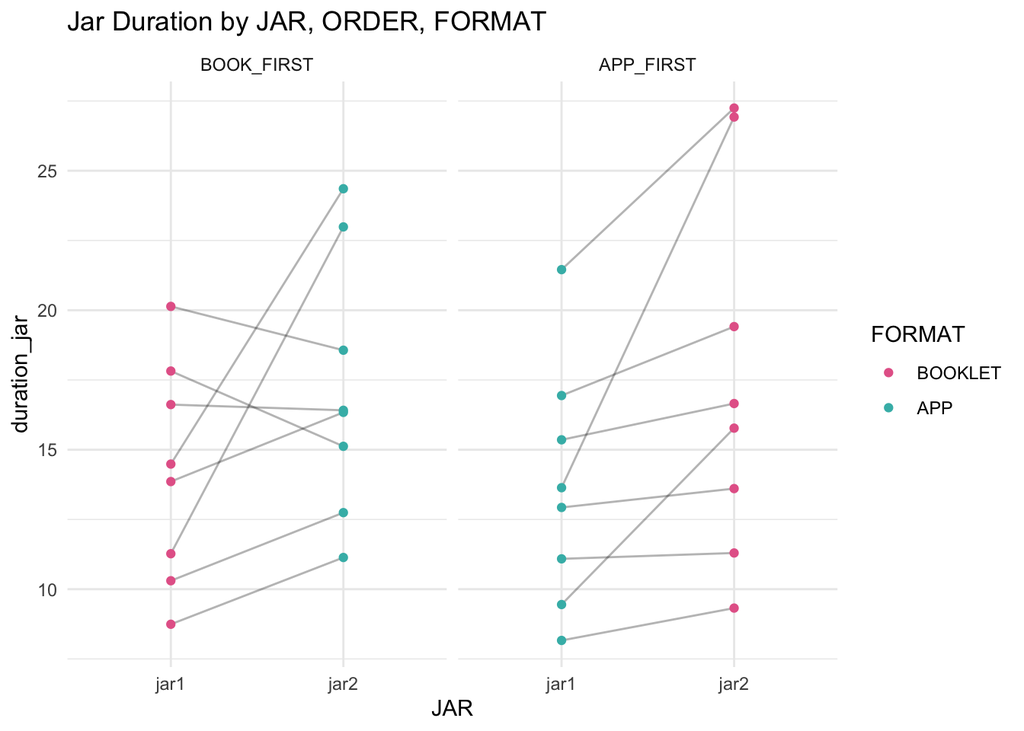

```r
## SET DATAFRAME
df <- df_tasks

## WITHIN-SUBJECTS LINEPLOT
(plot_duration <- df %>%
  ggplot(aes(JAR, duration_jar, group = PID, color=FORMAT)) +
    geom_line(alpha = .3, color = "black") +
    scale_color_manual(values = format_pal) +
  geom_point() +
  facet_wrap(~ORDER) +
  theme_minimal() +
  labs(title = "Jar Duration by JAR, ORDER, FORMAT"))
```

```r
ggsave(
  filename = "figs/poster/plot_duration_lineplot.svg",
  plot = plot_duration,
  device = svglite,
  width = 6,
  height = 4,
  units = "in"
)

## PRINT TABLE
(t <- df %>%
  mutate(duration_sec = round(duration_jar, 1)) %>%
  select(PID, JAR, FORMAT, ORDER, duration_sec, errors_jar) %>%
  gt() %>% tab_header("JAR DURATION table")
)
```

JAR DURATION table

| PID | JAR | FORMAT | ORDER | duration_sec | errors_jar |
| --- | --- | --- | --- | --- | --- |
| P01 | jar1 | BOOKLET | BOOK_FIRST | 11.3 | 8 |
| P01 | jar2 | APP | BOOK_FIRST | 23.0 | 7 |
| P02 | jar1 | BOOKLET | BOOK_FIRST | 13.9 | 3 |
| P02 | jar2 | APP | BOOK_FIRST | 16.3 | 1 |
| P03 | jar1 | APP | APP_FIRST | 16.9 | 0 |
| P03 | jar2 | BOOKLET | APP_FIRST | 19.4 | 8 |
| P04 | jar1 | APP | APP_FIRST | 13.6 | 3 |
| P04 | jar2 | BOOKLET | APP_FIRST | 26.9 | 5 |
| P05 | jar1 | BOOKLET | BOOK_FIRST | 20.1 | 6 |
| P05 | jar2 | APP | BOOK_FIRST | 18.6 | 2 |
| P06 | jar1 | APP | APP_FIRST | 12.9 | 5 |
| P06 | jar2 | BOOKLET | APP_FIRST | 13.6 | 4 |
| P07 | jar1 | BOOKLET | BOOK_FIRST | 10.3 | 2 |
| P07 | jar2 | APP | BOOK_FIRST | 12.7 | 1 |
| P14 | jar1 | APP | APP_FIRST | 11.1 | 4 |
| P14 | jar2 | BOOKLET | APP_FIRST | 11.3 | 3 |
| P15 | jar1 | BOOKLET | BOOK_FIRST | 8.7 | 1 |
| P15 | jar2 | APP | BOOK_FIRST | 11.1 | 0 |
| P16 | jar1 | APP | APP_FIRST | 8.2 | 1 |
| P16 | jar2 | BOOKLET | APP_FIRST | 9.3 | 1 |
| P08 | jar1 | APP | APP_FIRST | 15.4 | 0 |
| P08 | jar2 | BOOKLET | APP_FIRST | 16.7 | 2 |
| P09 | jar1 | BOOKLET | BOOK_FIRST | 17.8 | 4 |
| P09 | jar2 | APP | BOOK_FIRST | 15.1 | 0 |
| P10 | jar1 | BOOKLET | BOOK_FIRST | 14.5 | 3 |
| P10 | jar2 | APP | BOOK_FIRST | 24.4 | 26 |
| P12 | jar1 | BOOKLET | BOOK_FIRST | 16.6 | 3 |
| P12 | jar2 | APP | BOOK_FIRST | 16.4 | 2 |
| P13 | jar1 | APP | APP_FIRST | 9.5 | 5 |
| P13 | jar2 | BOOKLET | APP_FIRST | 15.8 | 16 |
| P17 | jar1 | APP | APP_FIRST | 21.5 | 4 |
| P17 | jar2 | BOOKLET | APP_FIRST | 27.2 | 10 |

```r
gtsave(
  t,
  filename = "figs/poster/duration_table.png"
)
```

```
## file:////var/folders/5f/c0q0_6zj1n1bbjjbsq6d73jr0000gn/T//RtmputwmKs/file106936b4b29c.html screenshot completed
```

#### model

```r
## LINEAR MIXED EFFECTS MODEL
m_jar_duration <- lmer(duration_jar ~ FORMAT + JAR + ORDER + (1 | PID), data = df)

## DIAGNOSTICS
# plot(m1)
# qqnorm(resid(m1))
# hist(resid(m1))

## MODEL TABLE
tab_model(m_jar_duration,
  show.se = TRUE,
  show.stat = TRUE,
  show.df = TRUE,
  show.re.var = TRUE,
  title = paste("Model:", deparse(formula(m_jar_duration))),
  file = "figs/poster/model_duration_table.html"
)
```

Model: duration_jar ~ FORMAT + JAR + ORDER + (1 | PID)

|  | duration jar |  |  |  |  |  |
| --- | --- | --- | --- | --- | --- | --- |
| Predictors | Estimates | std. Error | CI | Statistic | p | df |
| (Intercept) | 14.15 | 1.77 | 10.53 – 17.78 | 8.02 | **<0.001** | 26.00 |
| FORMAT [APP] | -0.42 | 1.21 | -2.90 – 2.05 | -0.35 | 0.728 | 26.00 |
| JAR [jar2] | 3.48 | 1.21 | 1.00 – 5.96 | 2.88 | **0.008** | 26.00 |
| ORDER [APP_FIRST] | -0.10 | 2.19 | -4.60 – 4.39 | -0.05 | 0.963 | 26.00 |
| Random Effects |  |  |  |  |  |  |
| σ<sup>2</sup> | 11.63 |  |  |  |  |  |
| τ<sub>00</sub> <sub>PID</sub> | 13.30 |  |  |  |  |  |
| ICC | 0.53 |  |  |  |  |  |
| N <sub>PID</sub> | 16 |  |  |  |  |  |
| Observations | 32 |  |  |  |  |  |
| Marginal R<sup>2</sup> / Conditional R<sup>2</sup> | 0.113 / 0.586 |  |  |  |  |  |

```r
## REPORT MODEL
report(m_jar_duration)
```

```
## We fitted a linear mixed model (estimated using REML and nloptwrap optimizer)
## to predict duration_jar with FORMAT, JAR and ORDER (formula: duration_jar ~
## FORMAT + JAR + ORDER). The model included PID as random effect (formula: ~1 |
## PID). The model's total explanatory power is substantial (conditional R2 =
## 0.59) and the part related to the fixed effects alone (marginal R2) is of 0.11.
## The model's intercept, corresponding to FORMAT = BOOKLET, JAR = jar1 and ORDER
## = BOOK_FIRST, is at 14.15 (95% CI [10.53, 17.78], t(26) = 8.02, p < .001).
## Within this model:
##
##   - The effect of FORMAT [APP] is statistically non-significant and negative
## (beta = -0.42, 95% CI [-2.90, 2.05], t(26) = -0.35, p = 0.728; Std. beta =
## -0.08, 95% CI [-0.57, 0.41])
##   - The effect of JAR [jar2] is statistically significant and positive (beta =
## 3.48, 95% CI [1.00, 5.96], t(26) = 2.88, p = 0.008; Std. beta = 0.69, 95% CI
## [0.20, 1.18])
##   - The effect of ORDER [APP_FIRST] is statistically non-significant and negative
## (beta = -0.10, 95% CI [-4.60, 4.39], t(26) = -0.05, p = 0.963; Std. beta =
## -0.02, 95% CI [-0.91, 0.87])
##
## Standardized parameters were obtained by fitting the model on a standardized
## version of the dataset. 95% Confidence Intervals (CIs) and p-values were
## computed using a Wald t-distribution approximation.
```

```r
## DESCRIBE MODEL VARIANCE EXPLAINED
v <- get_variance(m_jar_duration)
t <- v$var.fixed + v$var.random + v$var.residual
fixed <- v$var.fixed/t * 100
random <- v$var.random/t * 100
residual <- v$var.residual/t * 100
```

**MODEL INTERPRETATION** We fit a linear mixed effects model predicting jar duration by FORMAT, JAR and ORDER with PARTICIPANT as a random intercept. The model explained 59% variance in jar duration (R2conditional), with 11% explained by fixed effects, and 47% explained by participant individual differences, and 41% left unexplained. Among the fixed effects, only JAR was a statistically significant predictor, indicating that on average, total duration for Jar 2 was 3.48 minutes longer than Jar 1 (beta = 3.48, 95% CI [1.00, 5.96], t(26) = 2.88, p = 0.008)

**VARIANCE INTERPRETATION** The participant-level variance was 13.3 and the residual variance was 11.63.

*Fixed effects accounted for approximately 11.3% of the total variance, participant-level differences accounted for 47.3%, and 41.4% remained unexplained.*

PID: (Intercept) = Between-participant variability in overall jar duration Residual = Within-participant / observation-level variability not explained by the model ICC = Proportion of remaining variance attributable to participant differences

### ERROR RECOVERY (error level)

#### visualization

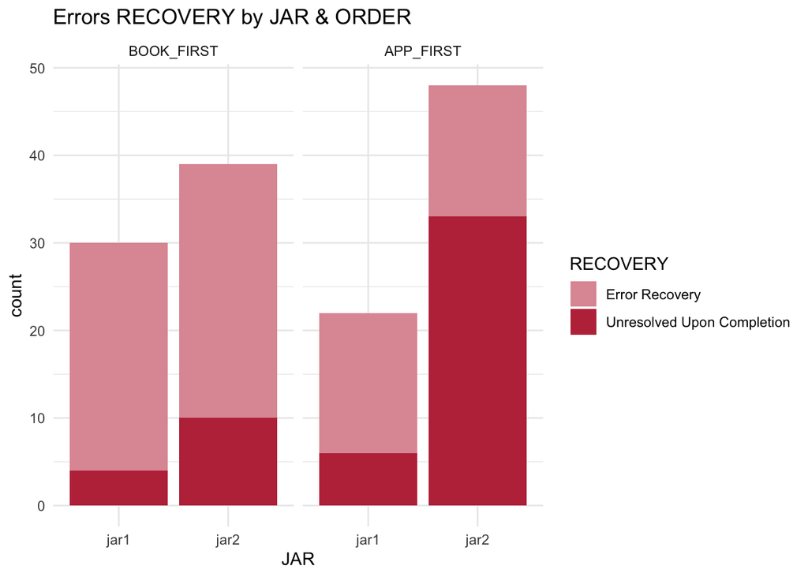

```r
df <- df_error_recoveries

## GROUPED BARCHART []
g <- df %>%
  ggplot(aes(x=JAR, fill=RECOVERY))+
    geom_bar() +
  scale_fill_manual(values = error_recovery_pal) +
  facet_wrap(~ORDER) +
  theme_minimal() +
  labs(title = "Errors RECOVERY by JAR & ORDER")

g
```

```r
ggsave(
  filename = "figs/poster/plot_errors_recovery.svg",
  plot = g,
  device = svglite,
  width = 6,
  height = 4,
  units = "in"
)


## SUMMARY TABLE
ds <- df %>%
  group_by(JAR, FORMAT, RECOVERY) %>%
  summarise(
    n_errors = n(),
    .groups = "drop"
  )

## PRINT TABLE
(t <- ds %>% gt() %>% tab_header("JAR ERROR RECOVERY table"))
```

JAR ERROR RECOVERY table

| JAR | FORMAT | RECOVERY | n_errors |
| --- | --- | --- | --- |
| jar1 | BOOKLET | Error Recovery | 26 |
| jar1 | BOOKLET | Unresolved Upon Completion | 4 |
| jar1 | APP | Error Recovery | 16 |
| jar1 | APP | Unresolved Upon Completion | 6 |
| jar2 | BOOKLET | Error Recovery | 15 |
| jar2 | BOOKLET | Unresolved Upon Completion | 33 |
| jar2 | APP | Error Recovery | 29 |
| jar2 | APP | Unresolved Upon Completion | 10 |

```r
gtsave(
  t,
  filename = "figs/poster/error_recovery_table.png"
)
```

```
## file:////var/folders/5f/c0q0_6zj1n1bbjjbsq6d73jr0000gn/T//RtmputwmKs/file106934d58beb7.html screenshot completed
```

#### model

```r
## one row per error
df <- df_error_recoveries |>
  droplevels() |>
   mutate(RECOVERY = fct_rev(RECOVERY))

m1 <- glmer(
  RECOVERY ~ FORMAT + JAR + (1 | PID),
  data = df,
  family = binomial(link = "logit")
)

m2 <- glmer(
  RECOVERY ~ FORMAT + JAR + ORDER + (1 | PID),
  data = df,
  family = binomial(link = "logit")
)

## note interaction model not appropriate given design

# report(m1)
report(m2)
```

```
## We fitted a logistic mixed model (estimated using ML and Nelder-Mead optimizer)
## to predict RECOVERY with FORMAT, JAR and ORDER (formula: RECOVERY ~ FORMAT +
## JAR + ORDER). The model included PID as random effect (formula: ~1 | PID). The
## model's total explanatory power is substantial (conditional R2 = 0.57) and the
## part related to the fixed effects alone (marginal R2) is of 0.22. The model's
## intercept, corresponding to FORMAT = BOOKLET, JAR = jar1 and ORDER =
## BOOK_FIRST, is at 2.40 (95% CI [0.48, 4.32], p = 0.014). Within this model:
##
##   - The effect of FORMAT [APP] is statistically non-significant and positive
## (beta = 1.07, 95% CI [-0.09, 2.23], p = 0.072; Std. beta = 1.07, 95% CI [-0.09,
## 2.23])
##   - The effect of JAR [jar2] is statistically non-significant and negative (beta
## = -1.08, 95% CI [-2.21, 0.05], p = 0.060; Std. beta = -1.08, 95% CI [-2.21,
## 0.05])
##   - The effect of ORDER [APP_FIRST] is statistically non-significant and negative
## (beta = -1.78, 95% CI [-4.02, 0.47], p = 0.121; Std. beta = -1.78, 95% CI
## [-4.02, 0.47])
##
## Standardized parameters were obtained by fitting the model on a standardized
## version of the dataset. 95% Confidence Intervals (CIs) and p-values were
## computed using a Wald z-distribution approximation.
```

```r
## MODEL TABLE
tab_model(m2,
  show.se = TRUE,
  show.stat = TRUE,
  show.df = TRUE,
  show.re.var = TRUE,
  title = paste("Model:", deparse(formula(m2))),
  file = "figs/poster/model_error_recovery_table.html"
)
```

Model: RECOVERY ~ FORMAT + JAR + ORDER + (1 | PID)

|  | RECOVERY |  |  |  |  |  |
| --- | --- | --- | --- | --- | --- | --- |
| Predictors | Odds Ratios | std. Error | CI | Statistic | p | df |
| (Intercept) | 11.03 | 10.83 | 1.61 – 75.49 | 2.45 | **0.014** | Inf |
| FORMAT [APP] | 2.91 | 1.73 | 0.91 – 9.31 | 1.80 | 0.072 | Inf |
| JAR [jar2] | 0.34 | 0.20 | 0.11 – 1.05 | -1.88 | 0.060 | Inf |
| ORDER [APP_FIRST] | 0.17 | 0.19 | 0.02 – 1.60 | -1.55 | 0.121 | Inf |
| Random Effects |  |  |  |  |  |  |
| σ<sup>2</sup> | 3.29 |  |  |  |  |  |
| τ<sub>00</sub> <sub>PID</sub> | 2.74 |  |  |  |  |  |
| ICC | 0.45 |  |  |  |  |  |
| N <sub>PID</sub> | 16 |  |  |  |  |  |
| Observations | 139 |  |  |  |  |  |
| Marginal R<sup>2</sup> / Conditional R<sup>2</sup> | 0.220 / 0.574 |  |  |  |  |  |

```r
## DESCRIBE MODEL VARIANCE EXPLAINED
v <- get_variance(m2)
t <- v$var.fixed + v$var.random + v$var.residual
fixed <- v$var.fixed/t * 100
random <- v$var.random/t * 100
residual <- v$var.residual/t * 100
```

**MODEL INTERPRETATION** We fit a logistic mixed effects model predicting error recovery by FORMAT, JAR and ORDER with PARTICIPANT as a random intercept. The model explained 57% variance in error recovery status (R2conditional), with 22% explained by fixed effects, and 35% explained by participant individual differences, and 42% left unexplained. Recovery was more likely in the app condition than the booklet condition, Recovery was somewhat lower for Jar 2 than Jar 1, though neither effect was statistically significant.

**VARIANCE INTERPRETATION** The participant-level variance was 2.74 and the residual variance was 3.29.

*Fixed effects accounted for approximately 22% of the total variance, participant-level differences accounted for 35.5%, and 42.6% remained unexplained.*

### ERROR TYPE

#### visualization

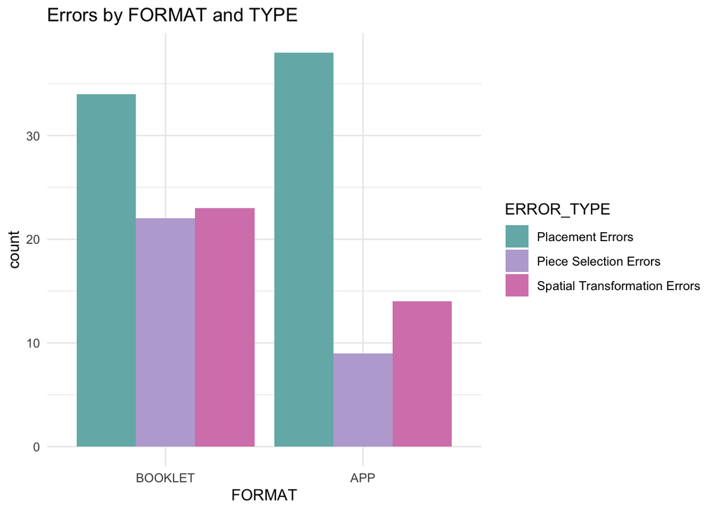

```r
## SET ERRORS DF
df <- df_errors

## GROUPED BARCHART [COUNT ERRORS X TYPE X FORMAT X ]
df %>%
  ggplot(aes(x=FORMAT, fill=ERROR_TYPE))+
    geom_bar(position="dodge") +
  scale_fill_manual(values = error_type_pal) +
  theme_minimal() +
  labs(title = "Errors by FORMAT and TYPE")
```

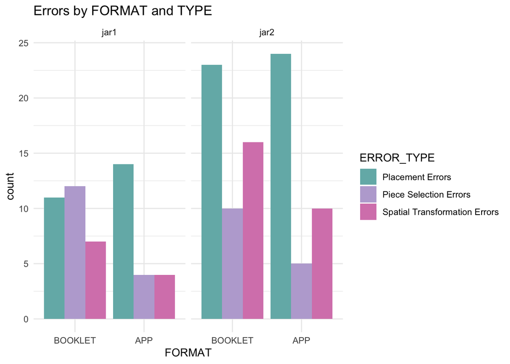

```r
## FACETED GROUPED BARCHART [COUNT ERRORS X TYPE X FORMAT X ]
df %>%
  ggplot(aes(x=FORMAT, fill=ERROR_TYPE))+
    geom_bar(position="dodge") +
  facet_wrap(~JAR) +
  scale_fill_manual(values = error_type_pal) +
  theme_minimal() +
  labs(title = "Errors by FORMAT and TYPE")
```

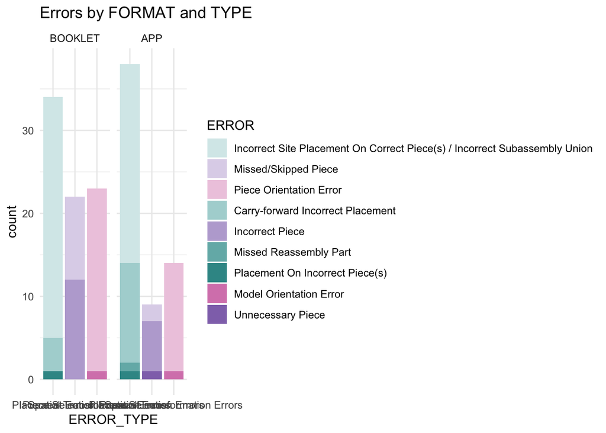

```r
## ZOES DETAIL GRAPH
(g <- df %>%
  ggplot(aes(x=ERROR_TYPE, fill=ERROR))+
    geom_bar(stat="count") +
  facet_wrap(~FORMAT) +
  scale_fill_manual(values = error_pal) +
  theme_minimal() +
  labs(title = "Errors by FORMAT and TYPE")
)
```

```r
ggsave(
  filename = "figs/poster/plot_errors_by_type.svg",
  plot = g,
  device = svglite,
  width = 10,
  height = 4,
  units = "in"
)

## MAKE SUMMARY TABLE
plot_df <- df %>%
  count(ERROR_TYPE, JAR, FORMAT, ERROR)

## PRINT TABLE
(t <- plot_df %>%
  gt() %>% tab_header("ERROR TYPE table")
)
```

ERROR TYPE table

| ERROR_TYPE | JAR | FORMAT | ERROR | n |
| --- | --- | --- | --- | --- |
| Placement Errors | jar1 | BOOKLET | Incorrect Site Placement On Correct Piece(s) / Incorrect Subassembly Union | 10 |
| Placement Errors | jar1 | BOOKLET | Placement On Incorrect Piece(s) | 1 |
| Placement Errors | jar1 | APP | Incorrect Site Placement On Correct Piece(s) / Incorrect Subassembly Union | 12 |
| Placement Errors | jar1 | APP | Missed Reassembly Part | 1 |
| Placement Errors | jar1 | APP | Placement On Incorrect Piece(s) | 1 |
| Placement Errors | jar2 | BOOKLET | Incorrect Site Placement On Correct Piece(s) / Incorrect Subassembly Union | 19 |
| Placement Errors | jar2 | BOOKLET | Carry-forward Incorrect Placement | 4 |
| Placement Errors | jar2 | APP | Incorrect Site Placement On Correct Piece(s) / Incorrect Subassembly Union | 12 |
| Placement Errors | jar2 | APP | Carry-forward Incorrect Placement | 12 |
| Piece Selection Errors | jar1 | BOOKLET | Missed/Skipped Piece | 5 |
| Piece Selection Errors | jar1 | BOOKLET | Incorrect Piece | 7 |
| Piece Selection Errors | jar1 | APP | Missed/Skipped Piece | 1 |
| Piece Selection Errors | jar1 | APP | Incorrect Piece | 2 |
| Piece Selection Errors | jar1 | APP | Unnecessary Piece | 1 |
| Piece Selection Errors | jar2 | BOOKLET | Missed/Skipped Piece | 5 |
| Piece Selection Errors | jar2 | BOOKLET | Incorrect Piece | 5 |
| Piece Selection Errors | jar2 | APP | Missed/Skipped Piece | 1 |
| Piece Selection Errors | jar2 | APP | Incorrect Piece | 4 |
| Spatial Transformation Errors | jar1 | BOOKLET | Piece Orientation Error | 7 |
| Spatial Transformation Errors | jar1 | APP | Piece Orientation Error | 3 |
| Spatial Transformation Errors | jar1 | APP | Model Orientation Error | 1 |
| Spatial Transformation Errors | jar2 | BOOKLET | Piece Orientation Error | 15 |
| Spatial Transformation Errors | jar2 | BOOKLET | Model Orientation Error | 1 |
| Spatial Transformation Errors | jar2 | APP | Piece Orientation Error | 10 |

```r
gtsave(
  t,
  filename = "figs/poster/error_type_table.png"
)
```

```
## file:////var/folders/5f/c0q0_6zj1n1bbjjbsq6d73jr0000gn/T//RtmputwmKs/file106937da1da1b.html screenshot completed
```

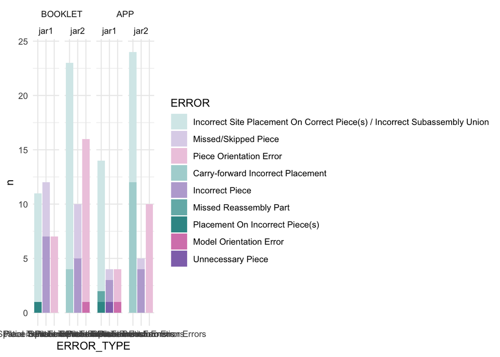

```r
## NESTED ERROR TYPE PLOT WITH JARS
(g <- plot_df %>%
  ggplot(aes(
    x = ERROR_TYPE,
    y = n,
    fill = ERROR
  )) +
  geom_col() +
  facet_nested(
    cols = vars(FORMAT, JAR),
    drop = TRUE
  ) +
  scale_fill_manual(values = error_pal) +
  theme_minimal())
```

```r
ggsave(
  filename = "figs/poster/plot_errors_by_type_NESTED.svg",
  plot = g,
  device = svglite,
  width = 10,
  height = 4,
  units = "in"
)
```

# THESIS

## DURATION

Are jar durations different for book versus app instructions, adjusting for JAR and ORDER, while accounting for participant-level speed differences?

**TLDR** : significant main effect of JAR; r2 conditional = 59% r2 marginal = 11%

### JAR DURATION

#### DESCRIBE Jar Duration

```r
## SET DATAFRAME
df_tasks %>% group_by(JAR) %>%
  summarise( min_dur = min(duration_jar),
             max_dur = max(duration_jar),
             m_dur = mean(duration_jar),
             sd_dur = sd(duration_jar))
```

```
## # A tibble: 2 × 5
##   JAR   min_dur max_dur m_dur sd_dur
##   <fct>   <dbl>   <dbl> <dbl>  <dbl>
## 1 jar1     8.16    21.5  13.9   3.99
## 2 jar2     9.32    27.2  17.4   5.54
```

#### VIS JAR Duration

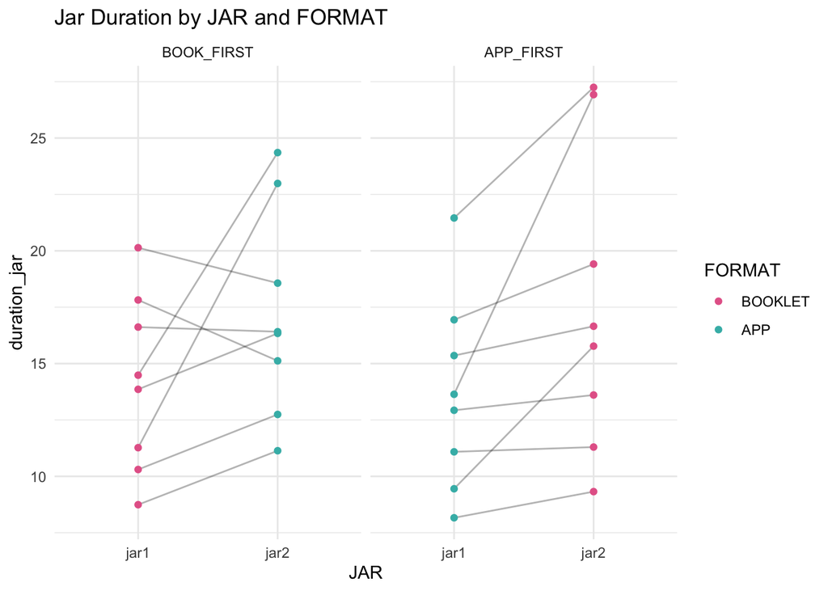

```r
## SET DATAFRAME
df <- df_tasks

## HISTOGRAM
# df %>% ggplot(aes(x=duration_jar)) +
#   geom_histogram(bins=10) +
#   theme_minimal()

## GGDIST DISTRIBITION
# df %>% ggplot(aes(x = duration_jar, y = FORMAT, fill=JAR)) +
#   stat_dotsinterval(
#     dotsize = 0.25, overflow = "compress"
#   ) +
#   facet_grid(JAR~., scales="fixed") +
#   labs (title = "Distribution of Jar Duration") +
#   theme_minimal() + guides(fill = "none")


## WITHIN-SUBJECTS LINEPLOT
df %>%
  ggplot(aes(JAR, duration_jar, group = PID, color=FORMAT)) +
    geom_line(alpha = .3, color = "black") +
    scale_color_manual(values = format_pal) +
  geom_point() +
  facet_wrap(~ORDER) +
  theme_minimal() +
  labs(title = "Jar Duration by JAR and FORMAT")
```

#### MODEL Jar Duration

```r
## SET DATAFRAME
df <- df_tasks

## MODEL
m1 <- lmer(duration_jar ~ FORMAT + JAR + ORDER + (1 | PID), data = df)

## DIAGNOSTICS
# plot(m1)
# qqnorm(resid(m1))
# hist(resid(m1))

## INTERPRET MODEL
model_parameters(m1)
```

```
## # Fixed Effects
##
## Parameter         | Coefficient |   SE |         95% CI | t(26) |      p
## ------------------------------------------------------------------------
## (Intercept)       |       14.15 | 1.77 | [10.53, 17.78] |  8.02 | < .001
## FORMAT [APP]      |       -0.42 | 1.21 | [-2.90,  2.05] | -0.35 | 0.728
## JAR [jar2]        |        3.48 | 1.21 | [ 1.00,  5.96] |  2.88 | 0.008
## ORDER [APP_FIRST] |       -0.10 | 2.19 | [-4.60,  4.39] | -0.05 | 0.963
##
## # Random Effects
##
## Parameter           | Coefficient |   SE |       95% CI
## -------------------------------------------------------
## SD (Intercept: PID) |        3.65 | 1.04 | [2.09, 6.36]
## SD (Residual)       |        3.41 | 0.64 | [2.35, 4.94]
```

```
##
## Uncertainty intervals (equal-tailed) and p-values (two-tailed) computed
##   using a Wald t-distribution approximation.
```

```r
performance(m1)
```

```
## # Indices of model performance
##
## AIC     |    AICc |     BIC | R2 (cond.) | R2 (marg.) |   ICC |  RMSE | Sigma
## -----------------------------------------------------------------------------
## 186.520 | 189.880 | 195.314 |      0.586 |      0.113 | 0.533 | 2.576 | 3.410
```

```r
report(m1)
```

```
## We fitted a linear mixed model (estimated using REML and nloptwrap optimizer)
## to predict duration_jar with FORMAT, JAR and ORDER (formula: duration_jar ~
## FORMAT + JAR + ORDER). The model included PID as random effect (formula: ~1 |
## PID). The model's total explanatory power is substantial (conditional R2 =
## 0.59) and the part related to the fixed effects alone (marginal R2) is of 0.11.
## The model's intercept, corresponding to FORMAT = BOOKLET, JAR = jar1 and ORDER
## = BOOK_FIRST, is at 14.15 (95% CI [10.53, 17.78], t(26) = 8.02, p < .001).
## Within this model:
##
##   - The effect of FORMAT [APP] is statistically non-significant and negative
## (beta = -0.42, 95% CI [-2.90, 2.05], t(26) = -0.35, p = 0.728; Std. beta =
## -0.08, 95% CI [-0.57, 0.41])
##   - The effect of JAR [jar2] is statistically significant and positive (beta =
## 3.48, 95% CI [1.00, 5.96], t(26) = 2.88, p = 0.008; Std. beta = 0.69, 95% CI
## [0.20, 1.18])
##   - The effect of ORDER [APP_FIRST] is statistically non-significant and negative
## (beta = -0.10, 95% CI [-4.60, 4.39], t(26) = -0.05, p = 0.963; Std. beta =
## -0.02, 95% CI [-0.91, 0.87])
##
## Standardized parameters were obtained by fitting the model on a standardized
## version of the dataset. 95% Confidence Intervals (CIs) and p-values were
## computed using a Wald t-distribution approximation.
```

#### MODEL VIS Jar Duration

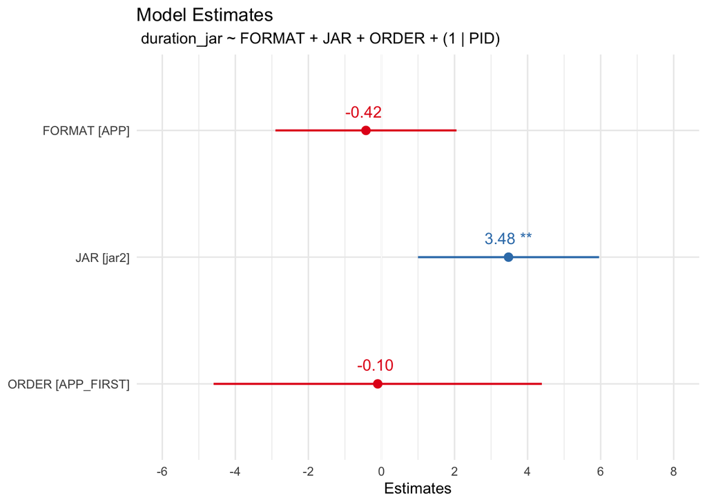

```r
## SET MODEL
m <- m1

## PLOT MODEL ESTIMATES
plot_model(m, type = "est", show.values = TRUE, show.p=TRUE) +
  labs( title = "Model Estimates",
    subtitle = paste("", deparse(formula(m1)))) +
  theme_minimal()
```

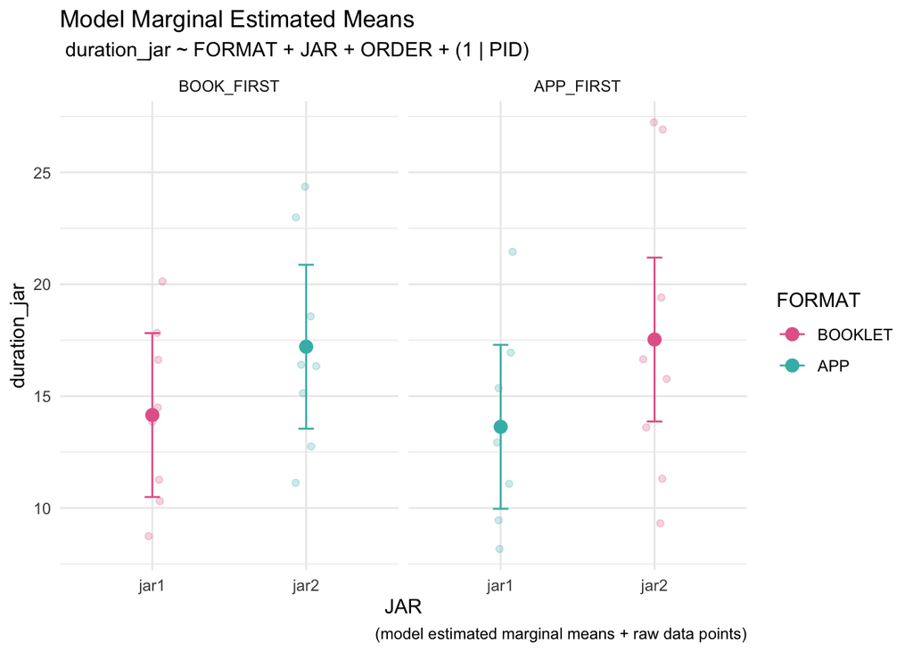

```r
## PLOT ESTIMATED MARGINAL MEANS
# p <- plot_model(m1, type = "emm",
#            terms = c("JAR","FORMAT","ORDER")) +
#   labs(
#     subtitle = "duration ~ FORMAT + JAR + ORDER + (1|PID)",
#     caption = "(estimated marginal means)") + theme_minimal()


## SET DATAFRAME
df <- df_tasks

## PLOT ESTIMATED MARGINAL MEANS WITH RAW DATA
# (g <- plot_model(
#   m,
#   type = "emm",
#   terms = c("JAR", "FORMAT", "ORDER")
# ) +
#     scale_color_manual(values = format_pal) +
#   geom_jitter(
#     data = df %>%
#       mutate(JAR_num = as.numeric(JAR)),
#     aes(
#       x = JAR_num,
#       y = duration_jar,
#       colour = FORMAT
#     ),
#     width = 0.08,
#     alpha = 0.20,
#     size = 1.5,
#     inherit.aes = FALSE
#   ) +
#   scale_x_continuous(
#     breaks = c(1, 2),
#     labels = c("jar1", "jar2")
#   ) +
#   labs(
#     subtitle = paste("", deparse(formula(m1))),
#     caption = "(model estimated marginal means + raw data points)"
#   ) +
#   theme_minimal())




###### VALID DESIGN CELLS ONLY
emm <- emmeans(m, ~ FORMAT + JAR + ORDER, type = "response")
emm_df <- as.data.frame(emm)

emm_df_valid <- emm_df %>%
  filter(
    (ORDER == "BOOK_FIRST" & JAR == "jar1" & FORMAT == "BOOKLET") |
    (ORDER == "BOOK_FIRST" & JAR == "jar2" & FORMAT == "APP") |
    (ORDER == "APP_FIRST"  & JAR == "jar1" & FORMAT == "APP") |
    (ORDER == "APP_FIRST"  & JAR == "jar2" & FORMAT == "BOOKLET")
  )

raw_df_valid <- df %>%
  filter(
    (ORDER == "BOOK_FIRST" & JAR == "jar1" & FORMAT == "BOOKLET") |
    (ORDER == "BOOK_FIRST" & JAR == "jar2" & FORMAT == "APP") |
    (ORDER == "APP_FIRST"  & JAR == "jar1" & FORMAT == "APP") |
    (ORDER == "APP_FIRST"  & JAR == "jar2" & FORMAT == "BOOKLET")
  )

ggplot() +
  scale_color_manual(values = format_pal) +
  geom_jitter(
    data = raw_df_valid,
    aes(x = JAR, y = duration_jar, color = FORMAT),
    width = 0.08,
    alpha = 0.25
  ) +
  geom_point(
    data = emm_df_valid,
    aes(x = JAR, y = emmean, color = FORMAT),
    size = 3
  ) +
  geom_errorbar(
    data = emm_df_valid,
    aes(
      x = JAR,
      ymin = lower.CL,
      ymax = upper.CL,
      color = FORMAT
    ),
    width = 0.10
  ) +
  facet_wrap(~ ORDER) +
   labs(
    title = "Model Marginal Estimated Means",
    subtitle = paste("", deparse(formula(m1))),
    caption = "(model estimated marginal means + raw data points)"
  ) +
  theme_minimal()
```

```r
ggsave(
  filename = "figs/thesis/plot_model_jar_duration_emm.svg",
  plot = g,
  device = svglite,
  width = 6,
  height = 4,
  units = "in"
)
```

#### MODEL TABLE Jar Duration

```r
## MODEL TABLE
(m_table <- tab_model(m1,
  show.se = TRUE,
  show.stat = TRUE,
  show.df = TRUE,
  show.re.var = TRUE,
  title = paste("Model:", deparse(formula(m1))))
)
```

Model: duration_jar ~ FORMAT + JAR + ORDER + (1 | PID)

|  | duration jar |  |  |  |  |  |
| --- | --- | --- | --- | --- | --- | --- |
| Predictors | Estimates | std. Error | CI | Statistic | p | df |
| (Intercept) | 14.15 | 1.77 | 10.53 – 17.78 | 8.02 | **<0.001** | 26.00 |
| FORMAT [APP] | -0.42 | 1.21 | -2.90 – 2.05 | -0.35 | 0.728 | 26.00 |
| JAR [jar2] | 3.48 | 1.21 | 1.00 – 5.96 | 2.88 | **0.008** | 26.00 |
| ORDER [APP_FIRST] | -0.10 | 2.19 | -4.60 – 4.39 | -0.05 | 0.963 | 26.00 |
| Random Effects |  |  |  |  |  |  |
| σ<sup>2</sup> | 11.63 |  |  |  |  |  |
| τ<sub>00</sub> <sub>PID</sub> | 13.30 |  |  |  |  |  |
| ICC | 0.53 |  |  |  |  |  |
| N <sub>PID</sub> | 16 |  |  |  |  |  |
| Observations | 32 |  |  |  |  |  |
| Marginal R<sup>2</sup> / Conditional R<sup>2</sup> | 0.113 / 0.586 |  |  |  |  |  |

```r
## DESCRIBE MODEL VARIANCE EXPLAINED
v <- get_variance(m1)
t <- v$var.fixed + v$var.random + v$var.residual
fixed <- v$var.fixed/t * 100
random <- v$var.random/t * 100
residual <- v$var.residual/t * 100
```

The participant-level variance was 13.3 and the residual variance was 11.63.

*Fixed effects accounted for approximately 11.3% of the total variance, participant-level differences accounted for 47.3%, and 41.4% remained unexplained.*

PID: (Intercept) = Between-participant variability in overall jar duration Residual = Within-participant / observation-level variability not explained by the model ICC = Proportion of remaining variance attributable to participant differences

### STEP DURATION

At the STEP level, each participant contributes 2 x (number of steps in a jar) data points; analysis with the `df_joined_steps_errors` dataframe. - PID is a random effect - STEP is nested within JAR

Are step durations different for book versus app instructions, adjusting for JAR and ORDER, while accounting for participant-level speed differences and step-level difficulty differences? (Note that setup and flipping/tapping steps are excluded)

#### DESCRIBE STEP Duration

```r
## SET DATAFRAME
df_joined_steps_errors %>% group_by(JAR) %>%
  summarise( min_dur = min(DURATION),
             max_dur = max(DURATION),
             m_dur = mean(DURATION),
             sd_dur = sd(DURATION))
```

```
## # A tibble: 2 × 5
##   JAR   min_dur max_dur m_dur sd_dur
##   <fct>   <dbl>   <dbl> <dbl>  <dbl>
## 1 jar1    0.200    159   23.5   22.1
## 2 jar2    0.400    264.  29.3   28.5
```

##### VIS STEP duration (book x format)

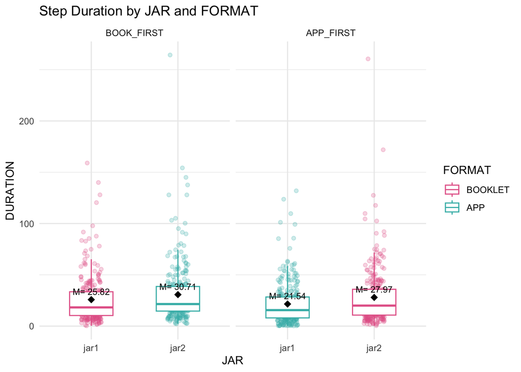

```r
## SET DATAFRAME
df <- df_joined_steps_errors

## GGDIST DISTRIBITION
# df %>% ggplot(aes(x = DURATION, y = FORMAT, fill=JAR)) +
#   stat_dotsinterval(
#     dotsize = 0.5, overflow = "compress"
#   ) +
#   facet_grid(JAR~., scales="fixed") +
#   labs (title = "Distribution of Step Duration") +
#   theme_minimal() + guides(fill = "none")


## STRIP PLOT
(g <- df %>%
  ggplot(aes(x = JAR, y = DURATION, color=FORMAT)) +
  geom_jitter(width = 0.12, alpha = 0.25) +
  scale_color_manual(values = format_pal) +
   # BOXPLOT
  geom_boxplot(
    aes(group = JAR),
    width = 0.5,
    outlier.shape = NA
  ) +
    # DISPLAY MEAN AS POINT
  stat_summary(
    fun = mean,
    geom = "point",
    shape = 18,
    size = 3,
    colour = "black"
  ) +
  # MEAN LABEL
  stat_summary(
    fun = mean,
    geom = "text",
    aes(label = paste("M=",sprintf("%.2f", after_stat(y)))),
    vjust = -0.8,
    colour = "black",
    size = 3
  ) +
  facet_grid(~ORDER) +
  labs( title = "Step Duration by JAR and FORMAT") +
  theme_minimal()
)
```

```r
ggsave(
  filename = "figs/thesis/plot_step_duration_boxplot.svg",
  plot = g,
  device = svglite,
  width = 6,
  height = 4,
  units = "in"
)
```

##### VIS STEP duration (complexity)

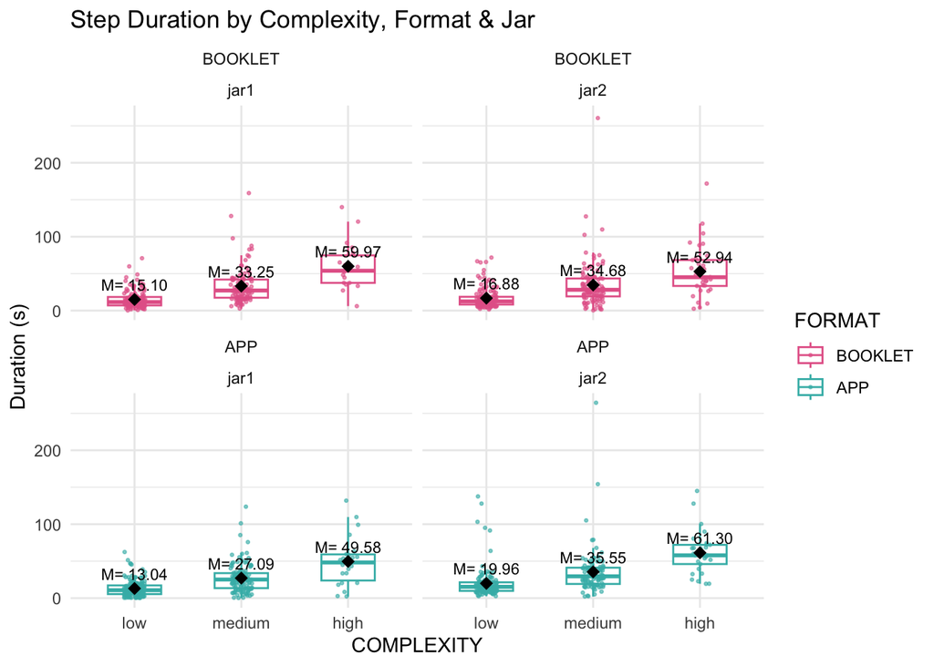

```r
## SET DATAFRAME
df <- df_joined_steps_errors

## PLOT RAW DATA
## STRIP PLOT + MEAN LABEL
(g <- ggplot(df,aes(x = COMPLEXITY, y = DURATION, colour = FORMAT)) +
  # BOXPLOT
  geom_boxplot(
    aes(group = COMPLEXITY),
    width = 0.5,
    outlier.shape = NA
  ) +
  scale_color_manual(values = format_pal) +
  geom_jitter(
    width = 0.1,
    alpha = 0.6,
    size = 0.5
  ) +
  # DISPLAY MEAN AS POINT
  stat_summary(
    fun = mean,
    geom = "point",
    shape = 18,
    size = 3,
    colour = "black"
  ) +
  # MEAN LABEL
  stat_summary(
    fun = mean,
    geom = "text",
    aes(label = paste("M=",sprintf("%.2f", after_stat(y)))),
    vjust = -0.8,
    colour = "black",
    size = 3
  ) +
  facet_wrap(FORMAT~ JAR) +
  theme_minimal() +
  labs(title = "Step Duration by Complexity, Format & Jar",
       y = "Duration (s)")
)
```

```r
ggsave(
  filename = "figs/thesis/plot_step_duration_by_complexity.svg",
  plot = g,
  device = svglite,
  width = 8,
  height = 8,
  units = "in"
)
```

##### VIS STEP duration (step)

[figure not shown]

```r
## STRIP PLOT
(g <- df %>%
  ggplot(aes(x = FORMAT, y = DURATION, color=FORMAT)) +
  geom_jitter(width = 0.12, alpha = 0.25) +
  scale_color_manual(values = format_pal) +
  geom_boxplot(width=-.25,  fill = NA)+
   # DISPLAY MEAN AS POINT
  stat_summary(
    fun = mean,
    geom = "point",
    shape = 18,
    size = 3,
    colour = "black"
  ) +
  # MEAN LABEL
  stat_summary(
    fun = mean,
    geom = "text",
    aes(label = paste("M=",sprintf("%.2f", after_stat(y)))),
    vjust = -0.8,
    colour = "black",
    size = 3
  ) +
  facet_wrap(~STEP) +
  labs( title = "Step Duration by STEP and FORMAT") +
  theme_minimal()
)
```

```r
ggsave(
  filename = "figs/raw/step_duration_by_step.svg",
  plot = g,
  device = svglite,
  width = 24,
  height = 24,
  units = "in"
)
```

#### MODEL STEP Duration (Simple Model)

```r
## SET DATAFRAME
df <- df_joined_steps_errors

## MODEL
m1 <- lmer(DURATION ~ FORMAT + JAR + ORDER + (1 | PID) + (1|STEP), data = df)

## DIAGNOSTICS
# plot(m1)
# qqnorm(resid(m1))
# hist(resid(m1))


## INTERPRET MODEL
# model_parameters(m1)
# performance(m1)
# report(m1)


## ESTIMATED MARGINAL MEANS
# emmeans(m1, ~ FORMAT)
# emmeans(m1, ~ JAR)


## PLOT MODEL ESTIMATES
# plot_model(m1, type = "est", show.values = TRUE, show.p=TRUE) +
#   labs( title = "Model Estimates",
#     subtitle = "duration ~ FORMAT + JAR + ORDER + (1|PID) + (1|STEP)") +
#   theme_minimal()


## PLOT ESTIMATED MARGINAL MEANS
# plot_model(m1, type = "emm",
#            terms = c("JAR","FORMAT")) +
#   labs(
#     subtitle = "duration ~ FORMAT + JAR + ORDER + (1|PID) + (1|STEP)") +
#     caption = "(estimated marginal means)") + theme_minimal()


## PLOT RANDOM EFFECTS
# plot_model(m1, type = "re")
```

#### MODEL STEP Duration (Complexity Model)

```r
## SET DATAFRAME
df <- df_joined_steps_errors

## MODEL
m2 <- lmer(DURATION ~ FORMAT + JAR + ORDER + COMPLEXITY + (1 | PID) + (1|STEP), data = df)
# m3 <- lmer(DURATION ~ JAR + ORDER + FORMAT * COMPLEXITY + (1 | PID) + (1|STEP), data = df) # no sig interaction


## DIAGNOSTICS
# plot(m2)
# qqnorm(resid(m2))
# hist(resid(m2))


## INTERPRET MODEL
# model_parameters(m2)
# performance(m2)
anova(m2)
```

```
## Type III Analysis of Variance Table with Satterthwaite's method
##            Sum Sq Mean Sq NumDF  DenDF F value Pr(>F)
## FORMAT         43    43.3     1 994.79  0.1164 0.7331
## JAR           904   903.5     1  54.68  2.4261 0.1251
## ORDER         161   161.5     1  14.03  0.4336 0.5209
## COMPLEXITY  34657 17328.4     2  53.40 46.5285  2e-12 ***
## ---
## Signif. codes:  0 '***' 0.001 '**' 0.01 '*' 0.05 '.' 0.1 ' ' 1
```

```r
report(m2)
```

```
## We fitted a linear mixed model (estimated using REML and nloptwrap optimizer)
## to predict DURATION with FORMAT, JAR, ORDER and COMPLEXITY (formula: DURATION ~
## FORMAT + JAR + ORDER + COMPLEXITY). The model included PID as random effects
## (formula: list(~1 | PID, ~1 | STEP)). The model's total explanatory power is
## substantial (conditional R2 = 0.45) and the part related to the fixed effects
## alone (marginal R2) is of 0.24. The model's intercept, corresponding to FORMAT
## = BOOKLET, JAR = jar1, ORDER = BOOK_FIRST and COMPLEXITY = low, is at 16.42
## (95% CI [8.98, 23.85], t(1056) = 4.33, p < .001). Within this model:
##
##   - The effect of FORMAT [APP] is statistically non-significant and negative
## (beta = -0.41, 95% CI [-2.75, 1.93], t(1056) = -0.34, p = 0.733; Std. beta =
## -0.02, 95% CI [-0.11, 0.08])
##   - The effect of JAR [jar2] is statistically non-significant and positive (beta
## = 3.87, 95% CI [-1.01, 8.76], t(1056) = 1.56, p = 0.120; Std. beta = 0.15, 95%
## CI [-0.04, 0.34])
##   - The effect of ORDER [APP_FIRST] is statistically non-significant and negative
## (beta = -2.91, 95% CI [-11.58, 5.76], t(1056) = -0.66, p = 0.510; Std. beta =
## -0.11, 95% CI [-0.45, 0.22])
##   - The effect of COMPLEXITY [medium] is statistically significant and positive
## (beta = 15.72, 95% CI [10.58, 20.86], t(1056) = 6.00, p < .001; Std. beta =
## 0.61, 95% CI [0.41, 0.81])
##   - The effect of COMPLEXITY [high] is statistically significant and positive
## (beta = 39.89, 95% CI [31.01, 48.77], t(1056) = 8.82, p < .001; Std. beta =
## 1.56, 95% CI [1.21, 1.90])
##
## Standardized parameters were obtained by fitting the model on a standardized
## version of the dataset. 95% Confidence Intervals (CIs) and p-values were
## computed using a Wald t-distribution approximation.
```

#### MODEL VIS STEP Duration (Complexity Model)

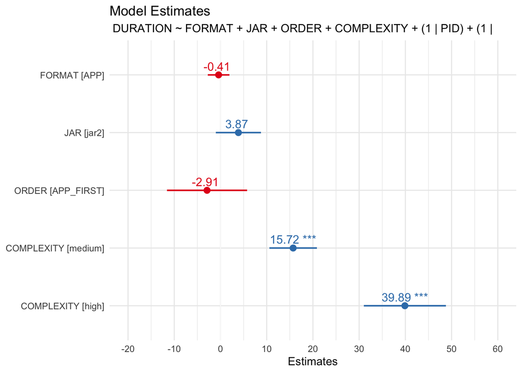

```r
## set model
m <- m2


## PLOT MODEL ESTIMATES
plot_model(m, type = "est", show.values = TRUE, show.p=TRUE) +
  labs( title = "Model Estimates",
    subtitle = paste("", deparse(formula(m2))))+
  theme_minimal()
```

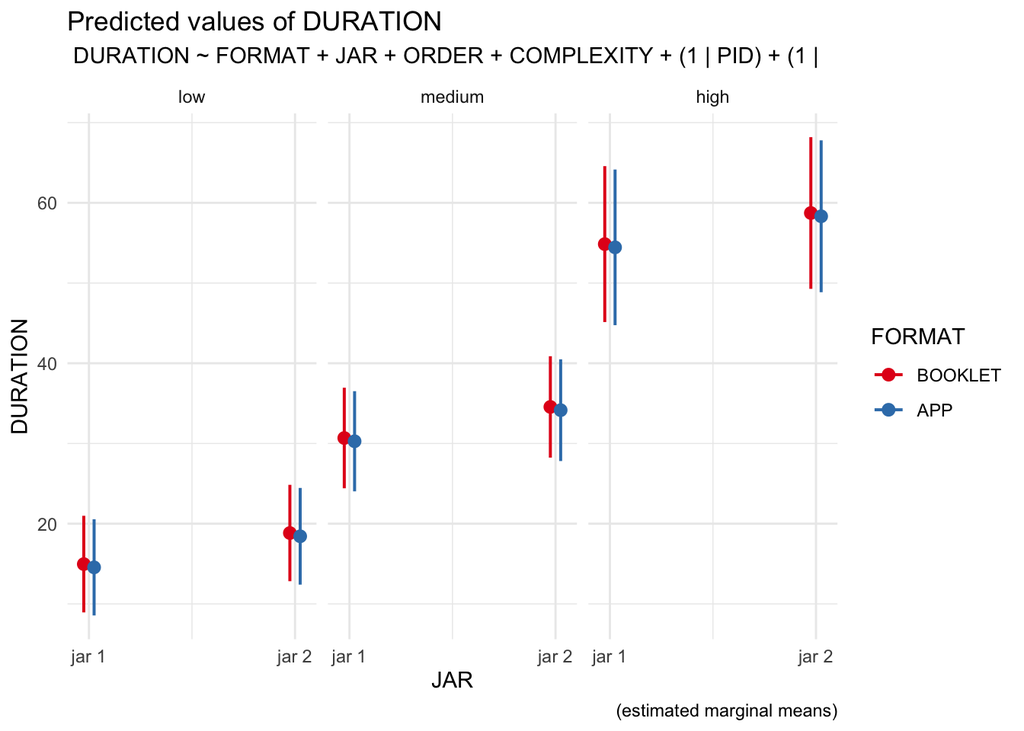

```r
## PLOT ESTIMATED MARGINAL MEANS
plot_model(m, type = "emm",
           terms = c("JAR","FORMAT","COMPLEXITY")) +
  labs(
     subtitle = paste("", deparse(formula(m2))),
      caption = "(estimated marginal means)") +
  theme_minimal()
```

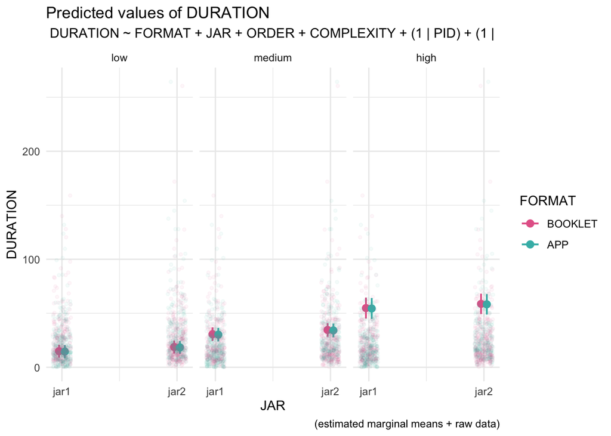

```r
## PLOT ESTIMATED MARGINAL MEANS WITH RAW DATA
(g <- plot_model(
   m,
   show.values = TRUE,
   type = "emm",
   terms = c("JAR", "FORMAT", "COMPLEXITY")
 ) +
   scale_color_manual(values = format_pal) +
   geom_jitter(
     data = df %>%
       mutate(
         JAR_num = case_when(
           JAR == "jar1" ~ 1,
           JAR == "jar2" ~ 2
         )
       ),
     aes(
       x = JAR_num,
       y = DURATION,
       colour = FORMAT
     ),
     width = 0.08,
     alpha = 0.05,
     size = 1,
     inherit.aes = FALSE
   ) +
   scale_x_continuous(
     breaks = c(1, 2),
     labels = c("jar1", "jar2")
   ) +
   labs(
     subtitle = paste("", deparse(formula(m2))),
     caption = "(estimated marginal means + raw data)"
   ) +
   theme_minimal()
)
```

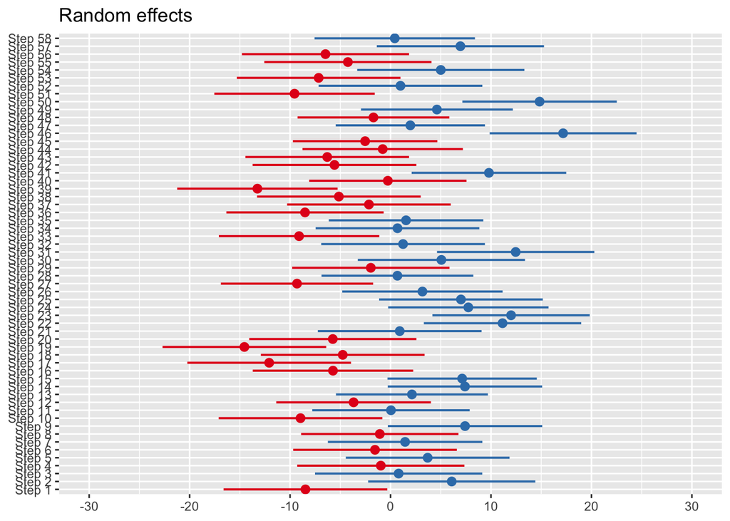

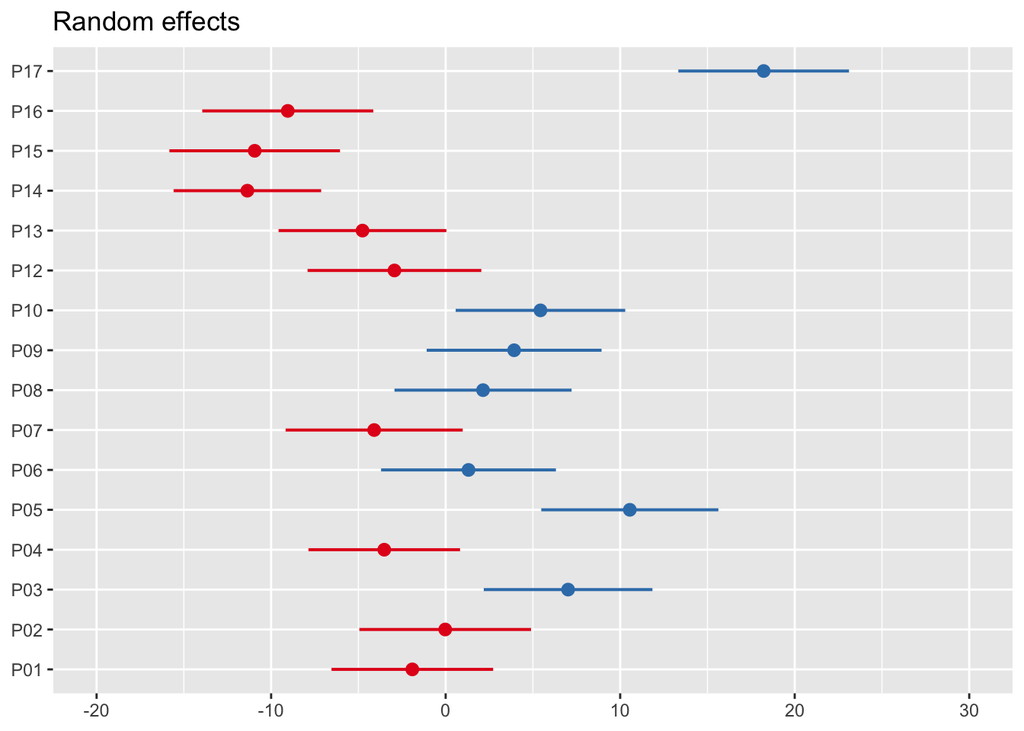

```r
 ggsave(
   filename = "figs/thesis/plot_model_step_duration_emm.svg",
   plot = g,
   device = svglite,
   width = 6,
   height = 4,
   units = "in"
 )



## PLOT RANDOM EFFECTS
plot_model(m2, type = "re")
```

#### MODEL TABLE Duration (Complexity Model)

```r
## MODEL TABLE
(tab_model(m2,
  show.se = TRUE,
  show.stat = TRUE,
  show.df = TRUE,
  show.re.var = TRUE
))
```

|  | DURATION |  |  |  |  |  |
| --- | --- | --- | --- | --- | --- | --- |
| Predictors | Estimates | std. Error | CI | Statistic | p | df |
| (Intercept) | 16.42 | 3.79 | 8.98 – 23.85 | 4.33 | **<0.001** | 1056.00 |
| FORMAT [APP] | -0.41 | 1.19 | -2.75 – 1.93 | -0.34 | 0.733 | 1056.00 |
| JAR [jar2] | 3.87 | 2.49 | -1.01 – 8.76 | 1.56 | 0.120 | 1056.00 |
| ORDER [APP_FIRST] | -2.91 | 4.42 | -11.58 – 5.76 | -0.66 | 0.510 | 1056.00 |
| COMPLEXITY [medium] | 15.72 | 2.62 | 10.58 – 20.86 | 6.00 | **<0.001** | 1056.00 |
| COMPLEXITY [high] | 39.89 | 4.53 | 31.01 – 48.77 | 8.82 | **<0.001** | 1056.00 |
| Random Effects |  |  |  |  |  |  |
| σ<sup>2</sup> | 372.43 |  |  |  |  |  |
| τ<sub>00</sub> <sub>STEP</sub> | 68.68 |  |  |  |  |  |
| τ<sub>00</sub> <sub>PID</sub> | 72.35 |  |  |  |  |  |
| ICC | 0.27 |  |  |  |  |  |
| N <sub>PID</sub> | 16 |  |  |  |  |  |
| N <sub>STEP</sub> | 58 |  |  |  |  |  |
| Observations | 1065 |  |  |  |  |  |
| Marginal R<sup>2</sup> / Conditional R<sup>2</sup> | 0.235 / 0.445 |  |  |  |  |  |

```r
## DESCRIBE MODEL VARIANCE EXPLAINED
v <- get_variance(m2)

# Random-intercept variance components by grouping factor
re_var <- as.data.frame(VarCorr(m2)) %>%
  filter(is.na(var2)) %>%
  select(group = grp, variance = vcov)

pid_var <- re_var %>%
  filter(group == "PID") %>%
  pull(variance)

step_var <- re_var %>%
  filter(group == "STEP") %>%
  pull(variance)

fixed_var <- v$var.fixed
residual_var <- v$var.residual

total_var <- fixed_var + pid_var + step_var + residual_var

fixed_pct <- 100 * fixed_var / total_var
pid_pct <- 100 * pid_var / total_var
step_pct <- 100 * step_var / total_var
residual_pct <- 100 * residual_var / total_var
```

The participant-level variance was 72.35, the step-level variance was 68.68, and the residual variance was 372.43.

*Fixed effects accounted for approximately 23.5% of the total variance, participant-level differences accounted for 10.8%, step-level differences accounted for 10.2%, and 55.5% remained unexplained.*

PID: (Intercept) = Between-participant variability in overall jar duration Residual = Within-participant / observation-level variability not explained by the model ICC = Proportion of remaining variance attributable to participant differences

## ERRORS

### ERROR COUNT

##### DESCRIBE Error Count

```r
## SET DATAFRAME
df_error_counts %>% group_by(JAR) %>%
  summarise( min_error = min(n_errors),
             max_error = max(n_errors),
             m_error = mean(n_errors),
             sd_error = sd(n_errors))
```

```
## # A tibble: 2 × 5
##   JAR   min_error max_error m_error sd_error
##   <fct>     <int>     <int>   <dbl>    <dbl>
## 1 jar1          0         8    3.25     2.18
## 2 jar2          0        26    5.5      6.96
```

```r
df_error_counts %>% group_by(FORMAT) %>%
  summarise( min_error = min(n_errors),
             max_error = max(n_errors),
             m_error = mean(n_errors),
             sd_error = sd(n_errors))
```

```
## # A tibble: 2 × 5
##   FORMAT  min_error max_error m_error sd_error
##   <fct>       <int>     <int>   <dbl>    <dbl>
## 1 APP             0        26    3.81     6.30
## 2 BOOKLET         1        16    4.94     3.94
```

##### VIS JAR Error Count

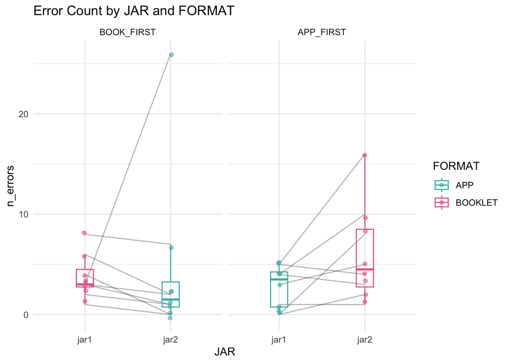

```r
## SET DATAFRAME
df <- df_error_counts

## GGPLOT LINE GRAPH WITHIN SUBJECTS
(g <- df %>%
  ggplot(aes(JAR, n_errors, group = PID, color=FORMAT)) +
  geom_line(alpha = .3, color="black") +
  geom_boxplot(
    aes(group = FORMAT),
    outlier.shape = NA,
    width = 0.2,
    fill = NA
  ) +
  scale_color_manual(values = format_pal) +
  geom_jitter(width = 0.01, alpha = 0.6) +
  facet_wrap(~ORDER) +
  theme_minimal() +
  labs(title = "Error Count by JAR and FORMAT")
)
```

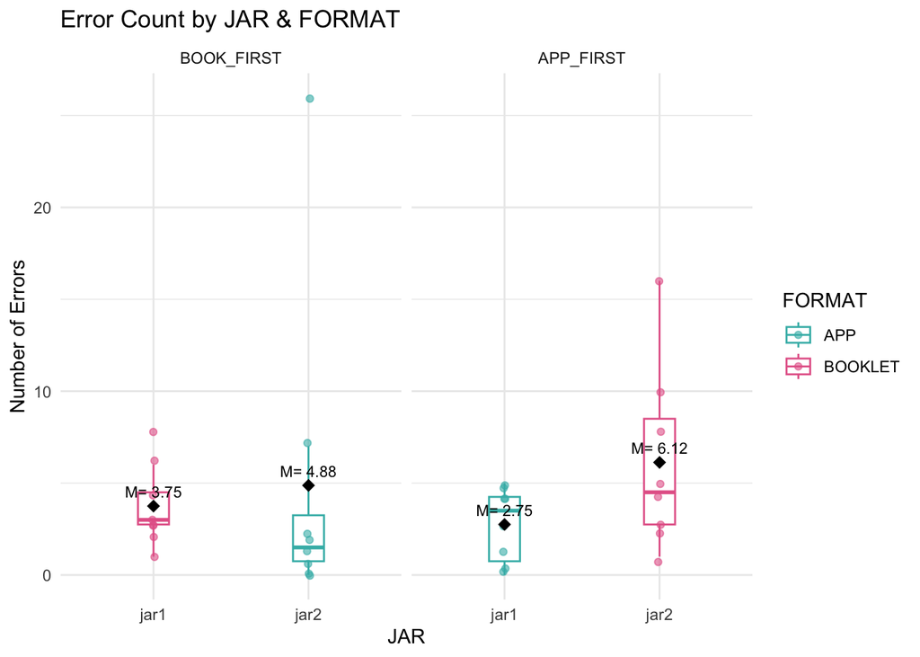

```r
ggsave(
  filename = "figs/thesis/plot_error_count_line.svg",
  plot = g,
  device = svglite,
  width = 6,
  height = 4,
  units = "in"
)
## ANOVA
# a <- aov_ez(
#   id = "PID",
#   dv = "n_errors",
#   within = c("FORMAT"),
#   between = c("ORDER"),
#   data = df
# )
# summary(a)

### BOXPLOT STRIP PLOT
df %>% ggplot(aes(x = JAR, y = n_errors, colour = FORMAT)) +
  geom_boxplot(
    aes(group = FORMAT),
    outlier.shape = NA,
    width = 0.2
  ) +
  scale_color_manual(values = format_pal) +
  geom_jitter(width = 0.01, alpha = 0.6) +
  # DISPLAY MEAN AS POINT
  stat_summary(
    fun = mean,
    geom = "point",
    shape = 18,
    size = 3,
    colour = "black"
  ) +
  # MEAN LABEL
  stat_summary(
    fun = mean,
    geom = "text",
    aes(label = paste("M=",sprintf("%.2f", after_stat(y)))),
    vjust = -0.8,
    colour = "black",
    size = 3
  ) +
  facet_wrap(~ ORDER) +
  theme_minimal() +
  labs(title = "Error Count by JAR & FORMAT",
       y = "Number of Errors")
```

##### MODEL JAR Error Count

What predicts number of errors?

```r
## SET DATAFRAME
df <- df_error_counts
# %>% filter(PID %nin% c("P10")) ## when filtering outlier; format becomes significant in m1

######## DROP OUTLINES
### DROP P10, P13
# df <- df |> filter(PID %nin% c("P10", "P13")) |> droplevels()

## MODEL 1 | Poisson model for count data
m1 <- glmer(
  n_errors ~ FORMAT + JAR  + ORDER + (1|PID),
  family = poisson,
  data = df
)

## MODEL 1 | Poisson model for count data
# m2 <- glmer(
#   n_errors ~ FORMAT * JAR  + (1|PID),
#   family = poisson,
#   data = df
# )


summary(m1)
```

```
## Generalized linear mixed model fit by maximum likelihood (Laplace
##   Approximation) [glmerMod]
##  Family: poisson  ( log )
## Formula: n_errors ~ FORMAT + JAR + ORDER + (1 | PID)
##    Data: df
##
##      AIC      BIC   logLik deviance df.resid
##    182.5    189.8    -86.2    172.5       27
##
## Scaled residuals:
##     Min      1Q  Median      3Q     Max
## -2.4937 -0.8559 -0.1528  0.7311  2.8897
##
## Random effects:
##  Groups Name        Variance Std.Dev.
##  PID    (Intercept) 0.5358   0.732
## Number of obs: 32, groups:  PID, 16
##
## Fixed effects:
##                Estimate Std. Error z value Pr(>|z|)
## (Intercept)     0.71595    0.32752   2.186  0.02882 *
## FORMATBOOKLET   0.26921    0.17367   1.550  0.12112
## JARjar2         0.53157    0.17367   3.061  0.00221 **
## ORDERAPP_FIRST  0.09571    0.41940   0.228  0.81948
## ---
## Signif. codes:  0 '***' 0.001 '**' 0.01 '*' 0.05 '.' 0.1 ' ' 1
##
## Correlation of Fixed Effects:
##             (Intr) FORMAT JARjr2
## FORMATBOOKL -0.247
## JARjar2     -0.312  0.054
## ORDERAPP_FI -0.608 -0.109 -0.057
```

```r
check_overdispersion(m1)
```

```
## # Overdispersion test
##
##        dispersion ratio =  1.448
##   Pearson's Chi-Squared = 39.103
##                 p-value =  0.062
```

```
## No overdispersion detected.
```

```r
# summary(m2)
# check_overdispersion(m2)
# compare_performance(m1,m2,rank=TRUE)
```

##### MODEL VIS JAR Error Count

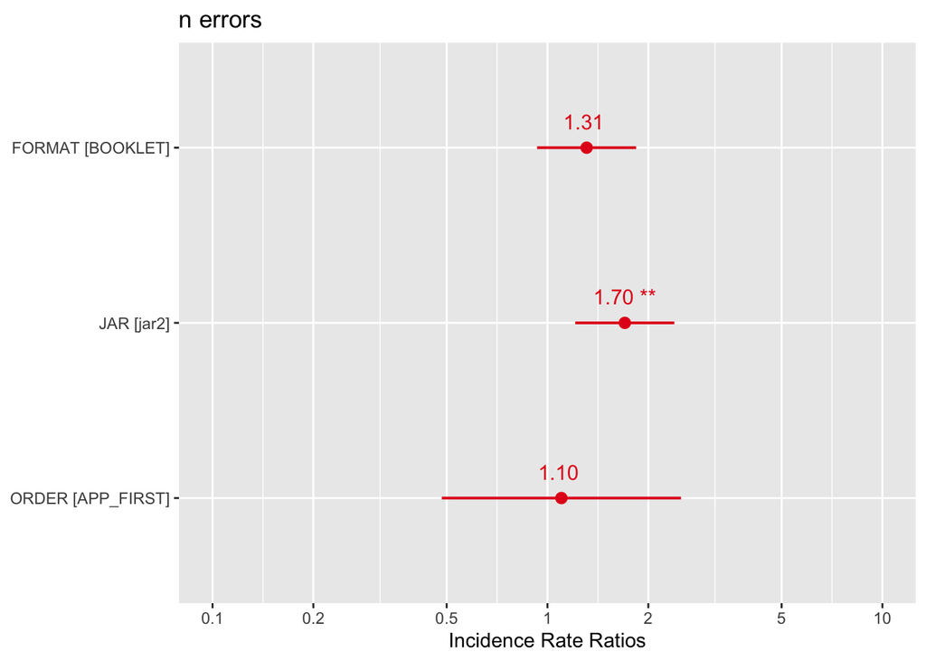

```r
## SET DATAFRAME
df <- df_error_counts

## set model
m <- m1

## PLOT MODEL ESTIMATES
# plot_model(m_pois, show.values= TRUE, type = "re") # random effects
## PLOT MODEL ESTIMATES
plot_model(m, show.values= TRUE, type = "est", show.p=TRUE)
```

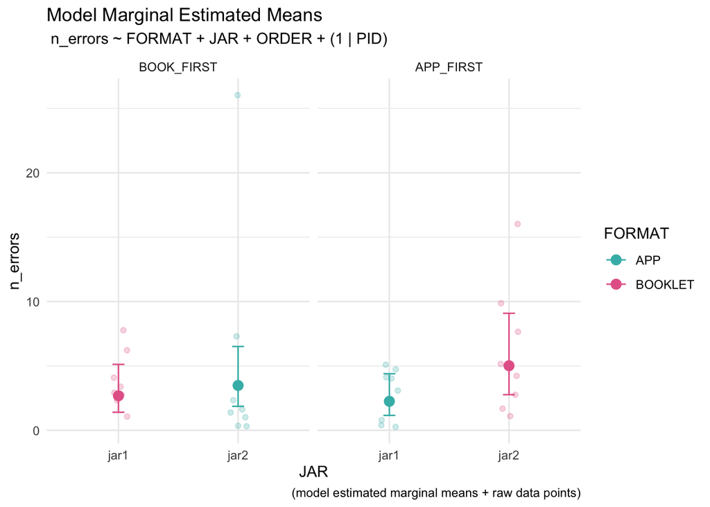

```r
## PLOT ESTIMATED MARGINAL MEANS WITH RAW DATA
# (g <- plot_model(
#   m,
#   bias_correction = TRUE,
#   type = "emm",
#   terms = c("JAR", "FORMAT", "ORDER")
# ) +
#   scale_color_manual(values = format_pal) +
#   geom_jitter(
#     data = df %>%
#       mutate(JAR = as.numeric(JAR)),
#     aes(
#       x = JAR,
#       y = n_errors,
#       colour = FORMAT
#     ),
#     width = 0.08,
#     alpha = 0.20,
#     size = 1.5,
#     inherit.aes = FALSE
#   ) +
#   # scale_x_continuous(
#   #   breaks = c(1, 2),
#   #   labels = c("jar1", "jar2")
#   # ) +
#   labs(
#     subtitle = paste("", deparse(formula(m1))),
#     caption = "(model estimated marginal means + raw data points)"
#   ) +
#   theme_minimal()
# )




###### VALID DESIGN CELLS ONLY
emm <- emmeans(m1, ~ FORMAT + JAR + ORDER, type = "response")

emm_df <- as.data.frame(emm)

emm_df_valid <- emm_df %>%
  filter(
    (ORDER == "BOOK_FIRST" & JAR == "jar1" & FORMAT == "BOOKLET") |
    (ORDER == "BOOK_FIRST" & JAR == "jar2" & FORMAT == "APP") |
    (ORDER == "APP_FIRST"  & JAR == "jar1" & FORMAT == "APP") |
    (ORDER == "APP_FIRST"  & JAR == "jar2" & FORMAT == "BOOKLET")
  )

raw_df_valid <- df %>%
  filter(
    (ORDER == "BOOK_FIRST" & JAR == "jar1" & FORMAT == "BOOKLET") |
    (ORDER == "BOOK_FIRST" & JAR == "jar2" & FORMAT == "APP") |
    (ORDER == "APP_FIRST"  & JAR == "jar1" & FORMAT == "APP") |
    (ORDER == "APP_FIRST"  & JAR == "jar2" & FORMAT == "BOOKLET")
  )

(g <- ggplot() +
  scale_color_manual(values = format_pal) +
  geom_jitter(
    data = raw_df_valid,
    aes(x = JAR, y = n_errors, color = FORMAT),
    width = 0.08,
    alpha = 0.25
  ) +
  geom_point(
    data = emm_df_valid,
    aes(x = JAR, y = rate, color = FORMAT),
    size = 3
  ) +
  geom_errorbar(
    data = emm_df_valid,
    aes(
      x = JAR,
      ymin = asymp.LCL,
      ymax = asymp.UCL,
      color = FORMAT
    ),
    width = 0.10
  ) +
  facet_wrap(~ ORDER) +
   labs(
    title = "Model Marginal Estimated Means",
    subtitle = paste("", deparse(formula(m1))),
    caption = "(model estimated marginal means + raw data points)"
  ) +
  theme_minimal()
)
```

```r
ggsave(
  filename = "figs/thesis/plot_model_jar_errorcount_emm.svg",
  plot = g,
  device = svglite,
  width = 6,
  height = 4,
  units = "in"
)
```